# TunicaLab

```python
import pandas as pd
import numpy as np
import seaborn as sns
import matplotlib.pyplot as plt
```

```python
df=pd.read_csv('Medicalpremium.csv')
df
```

|  | Age | Diabetes | BloodPressureProblems | AnyTransplants | AnyChronicDiseases | Height | Weight | KnownAllergies | HistoryOfCancerInFamily | NumberOfMajorSurgeries | PremiumPrice |
| --- | --- | --- | --- | --- | --- | --- | --- | --- | --- | --- | --- |
| 0 | 45 | 0 | 0 | 0 | 0 | 155 | 57 | 0 | 0 | 0 | 25000 |
| 1 | 60 | 1 | 0 | 0 | 0 | 180 | 73 | 0 | 0 | 0 | 29000 |
| 2 | 36 | 1 | 1 | 0 | 0 | 158 | 59 | 0 | 0 | 1 | 23000 |
| 3 | 52 | 1 | 1 | 0 | 1 | 183 | 93 | 0 | 0 | 2 | 28000 |
| 4 | 38 | 0 | 0 | 0 | 1 | 166 | 88 | 0 | 0 | 1 | 23000 |
| ... | ... | ... | ... | ... | ... | ... | ... | ... | ... | ... | ... |
| 981 | 18 | 0 | 0 | 0 | 0 | 169 | 67 | 0 | 0 | 0 | 15000 |
| 982 | 64 | 1 | 1 | 0 | 0 | 153 | 70 | 0 | 0 | 3 | 28000 |
| 983 | 56 | 0 | 1 | 0 | 0 | 155 | 71 | 0 | 0 | 1 | 29000 |
| 984 | 47 | 1 | 1 | 0 | 0 | 158 | 73 | 1 | 0 | 1 | 39000 |
| 985 | 21 | 0 | 0 | 0 | 0 | 158 | 75 | 1 | 0 | 1 | 15000 |

986 rows × 11 columns

# Data Inspection

```python
df.info()
```

```
<class 'pandas.core.frame.DataFrame'>
RangeIndex: 986 entries, 0 to 985
Data columns (total 11 columns):
 #   Column                   Non-Null Count  Dtype
---  ------                   --------------  -----
 0   Age                      986 non-null    int64
 1   Diabetes                 986 non-null    int64
 2   BloodPressureProblems    986 non-null    int64
 3   AnyTransplants           986 non-null    int64
 4   AnyChronicDiseases       986 non-null    int64
 5   Height                   986 non-null    int64
 6   Weight                   986 non-null    int64
 7   KnownAllergies           986 non-null    int64
 8   HistoryOfCancerInFamily  986 non-null    int64
 9   NumberOfMajorSurgeries   986 non-null    int64
 10  PremiumPrice             986 non-null    int64
dtypes: int64(11)
memory usage: 84.9 KB
```

```python
df.describe()
```

|  | Age | Diabetes | BloodPressureProblems | AnyTransplants | AnyChronicDiseases | Height | Weight | KnownAllergies | HistoryOfCancerInFamily | NumberOfMajorSurgeries | PremiumPrice |
| --- | --- | --- | --- | --- | --- | --- | --- | --- | --- | --- | --- |
| count | 986.000000 | 986.000000 | 986.000000 | 986.000000 | 986.000000 | 986.000000 | 986.000000 | 986.000000 | 986.000000 | 986.000000 | 986.000000 |
| mean | 41.745436 | 0.419878 | 0.468560 | 0.055781 | 0.180527 | 168.182556 | 76.950304 | 0.215010 | 0.117647 | 0.667343 | 24336.713996 |
| std | 13.963371 | 0.493789 | 0.499264 | 0.229615 | 0.384821 | 10.098155 | 14.265096 | 0.411038 | 0.322353 | 0.749205 | 6248.184382 |
| min | 18.000000 | 0.000000 | 0.000000 | 0.000000 | 0.000000 | 145.000000 | 51.000000 | 0.000000 | 0.000000 | 0.000000 | 15000.000000 |
| 25% | 30.000000 | 0.000000 | 0.000000 | 0.000000 | 0.000000 | 161.000000 | 67.000000 | 0.000000 | 0.000000 | 0.000000 | 21000.000000 |
| 50% | 42.000000 | 0.000000 | 0.000000 | 0.000000 | 0.000000 | 168.000000 | 75.000000 | 0.000000 | 0.000000 | 1.000000 | 23000.000000 |
| 75% | 53.000000 | 1.000000 | 1.000000 | 0.000000 | 0.000000 | 176.000000 | 87.000000 | 0.000000 | 0.000000 | 1.000000 | 28000.000000 |
| max | 66.000000 | 1.000000 | 1.000000 | 1.000000 | 1.000000 | 188.000000 | 132.000000 | 1.000000 | 1.000000 | 3.000000 | 40000.000000 |

## Inference :-

```
1. Min Age is 18 and Maximum age is 66.
2. Min premium Price is 15000 and max is 40000.
```

```python
df.isnull().sum()
```

```
Age                        0
Diabetes                   0
BloodPressureProblems      0
AnyTransplants             0
AnyChronicDiseases         0
Height                     0
Weight                     0
KnownAllergies             0
HistoryOfCancerInFamily    0
NumberOfMajorSurgeries     0
PremiumPrice               0
dtype: int64
```

```python
df.shape
```

```
(986, 11)
```

```python
D=df.duplicated()
D
```

```
0      False
1      False
2      False
3      False
4      False
       ...
981    False
982    False
983    False
984    False
985    False
Length: 986, dtype: bool
```

```python
D=df.duplicated().value_counts()
D
```

```
False    986
dtype: int64
```

```python
df.nunique()
```

```
Age                        49
Diabetes                    2
BloodPressureProblems       2
AnyTransplants              2
AnyChronicDiseases          2
Height                     44
Weight                     74
KnownAllergies              2
HistoryOfCancerInFamily     2
NumberOfMajorSurgeries      4
PremiumPrice               24
dtype: int64
```

# Observations:-

```
1.Data set has 986 Records and 11 Columns.
2.All Attributes has data type as integer.
3.No Null values are present in data set.
4.No Duplicate Records.
```

# Data Visualization

### We have to sort the data set 'Agewise'

```python
import matplotlib.pyplot as plt
```

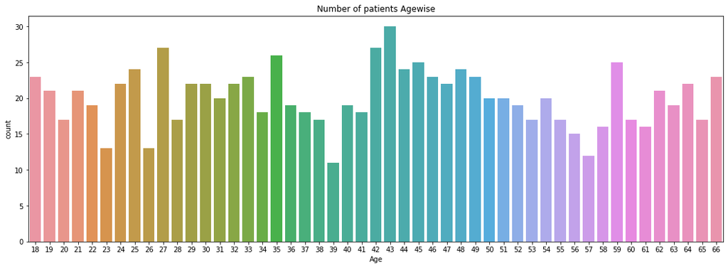

```python
from matplotlib import pyplot as plt
import seaborn as sns
plt.figure(figsize=(18,6))
sns.countplot (x='Age',data=df)
plt.xticks
plt.title('Number of patients Agewise')
plt.show()
```

## Inference :-In above bar plot , patients having age 43 has the highest records(30) and range of Age is 18 to 66.

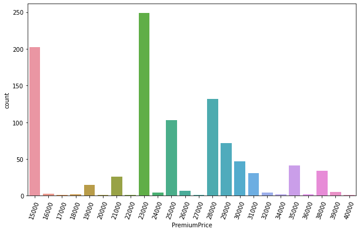

```python
plt.figure(figsize=(10, 6))
plt.xticks(rotation=70)
sns.countplot(x='PremiumPrice', data=df)
```

```python
df1=df[df['PremiumPrice']==23000]
df1
```

|  | Age | Diabetes | BloodPressureProblems | AnyTransplants | AnyChronicDiseases | Height | Weight | KnownAllergies | HistoryOfCancerInFamily | NumberOfMajorSurgeries | PremiumPrice |
| --- | --- | --- | --- | --- | --- | --- | --- | --- | --- | --- | --- |
| 2 | 36 | 1 | 1 | 0 | 0 | 158 | 59 | 0 | 0 | 1 | 23000 |
| 4 | 38 | 0 | 0 | 0 | 1 | 166 | 88 | 0 | 0 | 1 | 23000 |
| 5 | 30 | 0 | 0 | 0 | 0 | 160 | 69 | 1 | 0 | 1 | 23000 |
| 8 | 48 | 1 | 0 | 0 | 0 | 169 | 74 | 1 | 0 | 0 | 23000 |
| 9 | 38 | 0 | 0 | 0 | 0 | 182 | 93 | 0 | 0 | 0 | 23000 |
| ... | ... | ... | ... | ... | ... | ... | ... | ... | ... | ... | ... |
| 965 | 35 | 1 | 1 | 0 | 0 | 165 | 67 | 0 | 0 | 1 | 23000 |
| 967 | 42 | 1 | 1 | 0 | 0 | 152 | 67 | 1 | 0 | 1 | 23000 |
| 970 | 46 | 1 | 1 | 0 | 0 | 168 | 75 | 0 | 0 | 1 | 23000 |
| 972 | 31 | 0 | 1 | 0 | 0 | 152 | 75 | 1 | 0 | 1 | 23000 |
| 975 | 44 | 0 | 1 | 0 | 0 | 161 | 75 | 0 | 0 | 0 | 23000 |

249 rows × 11 columns

```python
Avg_users=df1['Age'].mean()
Avg_users
```

```
38.437751004016064
```

## Inference:-

[output not shown]

```python
df['Age'].value_counts()  # To varify lets crosscheck the data.
```

```
43    30
42    27
27    27
35    26
59    25
45    25
25    24
44    24
48    24
49    23
33    23
46    23
66    23
18    23
47    22
```

[output cut: 35 more lines]

```python
df.sort_values('Age')
```

|  | Age | Diabetes | BloodPressureProblems | AnyTransplants | AnyChronicDiseases | Height | Weight | KnownAllergies | HistoryOfCancerInFamily | NumberOfMajorSurgeries | PremiumPrice |
| --- | --- | --- | --- | --- | --- | --- | --- | --- | --- | --- | --- |
| 476 | 18 | 0 | 0 | 0 | 0 | 181 | 65 | 1 | 1 | 1 | 15000 |
| 795 | 18 | 0 | 0 | 0 | 0 | 148 | 75 | 1 | 0 | 0 | 15000 |
| 722 | 18 | 0 | 0 | 0 | 0 | 172 | 71 | 0 | 0 | 0 | 15000 |
| 822 | 18 | 0 | 1 | 0 | 0 | 163 | 82 | 0 | 0 | 0 | 15000 |
| 580 | 18 | 0 | 0 | 0 | 0 | 172 | 79 | 0 | 0 | 0 | 15000 |
| ... | ... | ... | ... | ... | ... | ... | ... | ... | ... | ... | ... |
| 959 | 66 | 0 | 1 | 0 | 0 | 153 | 75 | 0 | 0 | 2 | 28000 |
| 678 | 66 | 1 | 0 | 0 | 1 | 165 | 100 | 0 | 0 | 0 | 35000 |
| 41 | 66 | 1 | 1 | 0 | 0 | 179 | 96 | 0 | 0 | 2 | 28000 |
| 550 | 66 | 1 | 1 | 0 | 0 | 168 | 85 | 0 | 0 | 2 | 28000 |
| 966 | 66 | 0 | 1 | 0 | 1 | 176 | 71 | 1 | 0 | 1 | 35000 |

986 rows × 11 columns

## Lets Find Correlation of Premium Price with Rest of Attribiutes

```python
df[["Age", "PremiumPrice"]].corr()
```

|  | Age | PremiumPrice |
| --- | --- | --- |
| Age | 1.00000 | 0.69754 |
| PremiumPrice | 0.69754 | 1.00000 |

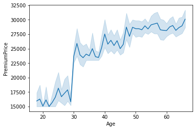

```python
sns.lineplot(df['Age'],df['PremiumPrice'])
```

## Inference:-Above Graph shows Age Vs PremiumPrice

### As age Grows Premium Price Increases.

```python
df[["Diabetes", "PremiumPrice"]].corr()
```

|  | Diabetes | PremiumPrice |
| --- | --- | --- |
| Diabetes | 1.000000 | 0.076209 |
| PremiumPrice | 0.076209 | 1.000000 |

```python
df[["BloodPressureProblems", "PremiumPrice"]].corr()
```

|  | BloodPressureProblems | PremiumPrice |
| --- | --- | --- |
| BloodPressureProblems | 1.000000 | 0.167097 |
| PremiumPrice | 0.167097 | 1.000000 |

```python
df[["Weight", "PremiumPrice"]].corr()
```

|  | Weight | PremiumPrice |
| --- | --- | --- |
| Weight | 1.000000 | 0.141507 |
| PremiumPrice | 0.141507 | 1.000000 |

```python
df[["AnyTransplants", "PremiumPrice"]].corr()
```

|  | AnyTransplants | PremiumPrice |
| --- | --- | --- |
| AnyTransplants | 1.000000 | 0.289056 |
| PremiumPrice | 0.289056 | 1.000000 |

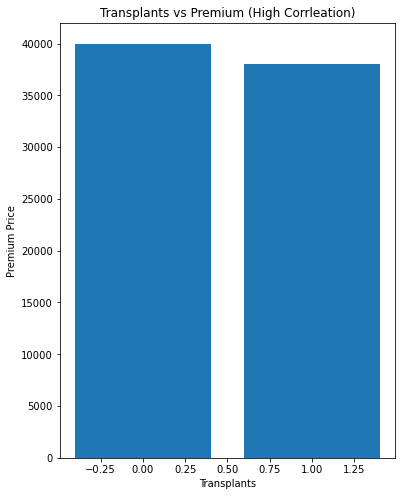

```python
plt.figure(figsize=(6,8))
plt.bar(df['AnyTransplants'], df['PremiumPrice'])
plt.xlabel('Transplants')
plt.ylabel('Premium Price')
plt.title('Transplants vs Premium (High Corrleation)')
plt.show()
```

```python
df[["NumberOfMajorSurgeries", "PremiumPrice"]].corr()
```

|  | NumberOfMajorSurgeries | PremiumPrice |
| --- | --- | --- |
| NumberOfMajorSurgeries | 1.00000 | 0.26425 |
| PremiumPrice | 0.26425 | 1.00000 |

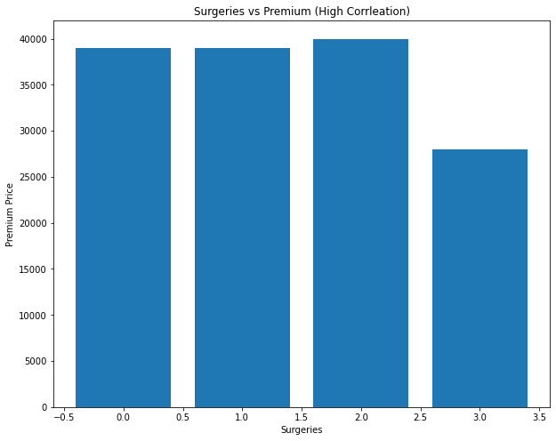

```python
plt.figure(figsize=(10,8))
plt.bar(df['NumberOfMajorSurgeries'], df['PremiumPrice'])
plt.xlabel('Surgeries')
plt.ylabel('Premium Price')
plt.title('Surgeries vs Premium (High Corrleation)')
plt.show()
```

## Inference :- Patients who went through Surgeries also paid high premium Price.

```python
df[["HistoryOfCancerInFamily", "PremiumPrice"]].corr()
```

|  | HistoryOfCancerInFamily | PremiumPrice |
| --- | --- | --- |
| HistoryOfCancerInFamily | 1.000000 | 0.083139 |
| PremiumPrice | 0.083139 | 1.000000 |

```python
 df[["KnownAllergies", "PremiumPrice"]].corr()
```

|  | KnownAllergies | PremiumPrice |
| --- | --- | --- |
| KnownAllergies | 1.000000 | 0.012103 |
| PremiumPrice | 0.012103 | 1.000000 |

## Inference:- Age is the most important Criteria for premium price.Correlation is 70%.

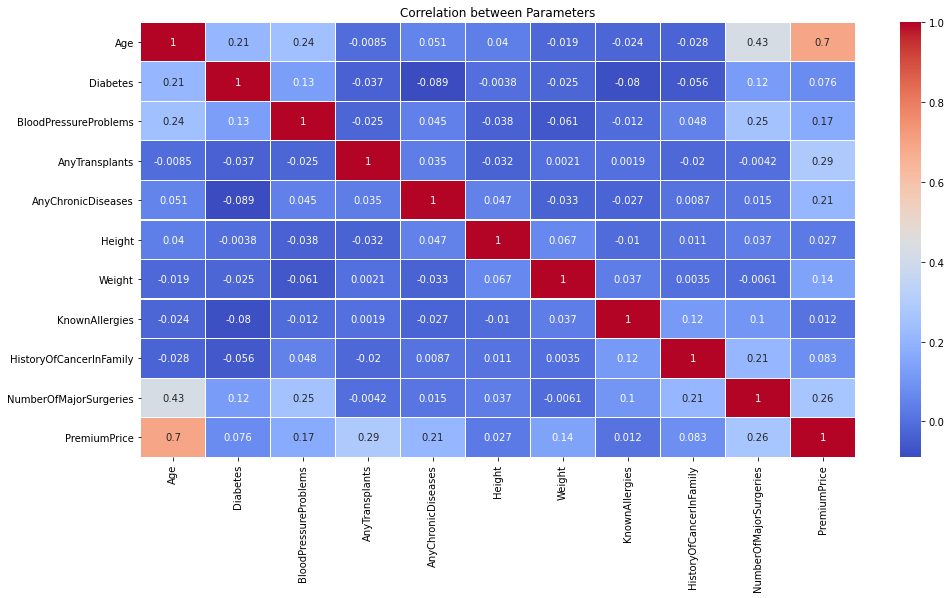

```python
# Let's Plot Heatmap
plt.figure(figsize=(16,8))
sns.heatmap(df.corr(), annot = True, cmap='coolwarm',linewidths=.1)
plt.title("Correlation between Parameters")
plt.show()
```

## Inference :-

### Most Important Parameters correlated with premium are :-Age(70%) , Numbers of transplants(29%), No. Of Measures surgeries(26%),Chronic Diseases(21%).

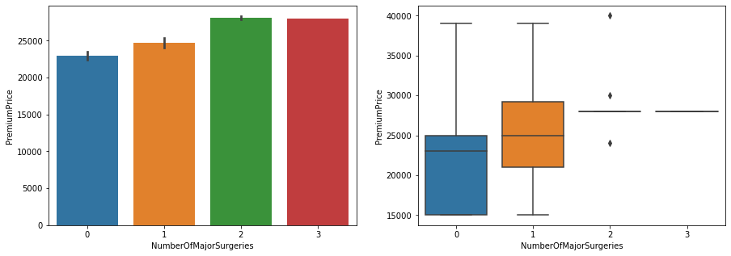

```python
f,ax=plt.subplots(1,2,figsize=(15,5))
sns.barplot(data = df, x='NumberOfMajorSurgeries',y='PremiumPrice',ax=ax[0])
sns.boxplot(data = df, x='NumberOfMajorSurgeries',y='PremiumPrice',ax=ax[1])
```

```python
df[df['NumberOfMajorSurgeries']==3]
```

|  | Age | Diabetes | BloodPressureProblems | AnyTransplants | AnyChronicDiseases | Height | Weight | KnownAllergies | HistoryOfCancerInFamily | NumberOfMajorSurgeries | PremiumPrice |
| --- | --- | --- | --- | --- | --- | --- | --- | --- | --- | --- | --- |
| 34 | 64 | 1 | 0 | 0 | 0 | 172 | 85 | 0 | 0 | 3 | 28000 |
| 91 | 63 | 1 | 1 | 0 | 0 | 175 | 95 | 0 | 0 | 3 | 28000 |
| 109 | 64 | 1 | 0 | 0 | 0 | 187 | 53 | 0 | 0 | 3 | 28000 |
| 274 | 64 | 1 | 0 | 0 | 0 | 163 | 88 | 0 | 0 | 3 | 28000 |
| 282 | 64 | 1 | 0 | 0 | 0 | 175 | 81 | 0 | 0 | 3 | 28000 |
| 309 | 64 | 1 | 0 | 0 | 0 | 177 | 94 | 0 | 0 | 3 | 28000 |
| 401 | 65 | 1 | 1 | 0 | 0 | 167 | 52 | 0 | 0 | 3 | 28000 |
| 458 | 61 | 1 | 0 | 0 | 0 | 178 | 71 | 0 | 0 | 3 | 28000 |
| 463 | 65 | 1 | 0 | 0 | 0 | 184 | 78 | 0 | 0 | 3 | 28000 |
| 605 | 62 | 0 | 0 | 0 | 0 | 177 | 97 | 0 | 0 | 3 | 28000 |
| 817 | 65 | 1 | 0 | 1 | 0 | 171 | 94 | 0 | 0 | 3 | 28000 |
| 818 | 65 | 1 | 0 | 0 | 0 | 165 | 99 | 0 | 0 | 3 | 28000 |
| 860 | 61 | 1 | 0 | 0 | 0 | 161 | 66 | 0 | 0 | 3 | 28000 |
| 953 | 62 | 1 | 1 | 0 | 0 | 157 | 66 | 0 | 0 | 3 | 28000 |
| 954 | 63 | 1 | 1 | 0 | 0 | 158 | 73 | 0 | 0 | 3 | 28000 |
| 982 | 64 | 1 | 1 | 0 | 0 | 153 | 70 | 0 | 0 | 3 | 28000 |

## Inference :- There are very few Patients who went through 2 or 3 surgeries who paid high Premium.

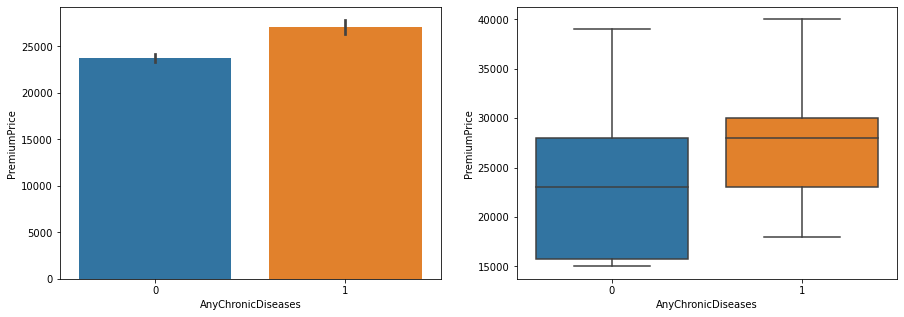

```python
f,ax=plt.subplots(1,2,figsize=(15,5))
sns.barplot(data = df, x='AnyChronicDiseases',y='PremiumPrice',ax=ax[0])
sns.boxplot(data = df, x='AnyChronicDiseases',y='PremiumPrice',ax=ax[1])
```

## Inference:-Patients who has one Chronic Disease is paying more Premium.

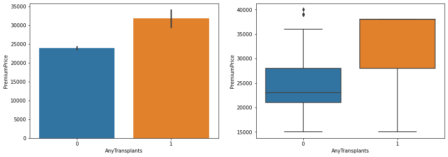

```python
f,ax=plt.subplots(1,2,figsize=(15,5))
sns.barplot(data = df, x='AnyTransplants',y='PremiumPrice',ax=ax[0])
sns.boxplot(data = df, x='AnyTransplants',y='PremiumPrice',ax=ax[1])
```

## Inference:-Patients who has one Transplant is paying more Premium.

# Machine Learning Model

```python
from sklearn.preprocessing import StandardScaler
from sklearn.model_selection import train_test_split
from sklearn.ensemble import RandomForestRegressor
```

```python
X = df.drop('PremiumPrice',axis=1) # Dependent Variable
y = df.PremiumPrice                # Independent Variable
```

```python
scalar =  StandardScaler()
X.Age = scalar.fit_transform(X[['Age']])
X.AnyTransplants = scalar.fit_transform(X[['AnyTransplants']])
X.NumberOfMajorSurgeries = scalar.fit_transform(X[['NumberOfMajorSurgeries']])
# Normalization scales each input variable separately to the range 0-1
```

```python
X_train,X_test,y_train,y_test = train_test_split(X,y,test_size=0.25,random_state=43)
# Train test split Data 75:25
```

```python
# Random Forest Regressor

Lr=RandomForestRegressor(n_estimators= 50,max_depth=5)
Lr_model=Lr.fit(X_train,y_train)
```

```python
print('Accuracy of the model on Training Dataset ',Lr_model.score(X_train,y_train))
print ('Accuracy of the model on Test Dataset ',Lr_model.score(X_test,y_test))
```

```
Accuracy of the model on Training Dataset  0.8492475858815967
Accuracy of the model on Test Dataset  0.820561541465377
```

## 6.As Age grows Premium Price Increases.

## 7.There are very Few users who went through 2 & 3 surgeries who paid high Premium.

## 8.Users who has one chronic disease is paying more premium, but they are less in numbers as compare to users with zero chronic disease.

## 9.Users who has one Transplant is paying more premium, but they are less in numbersas compare to users with zero Transplants.

## 10.Most important parameters correlated with Premium Price are :-

## Age (70%), No. of Transplants(29%),No.of surgeries(26%),Chronic Diseases(21%).

## Age is the Most Important Parameter for Premium Price.